# Cruzando e limpando dados com os pacotes dplyr e tidyr

Alessandro Freire

05 julho, 2019

# Cruzando dados com o dplyr

O pacote `dplyr` oferece uma série de funções que permitem o cruzamento de dados de forma fácil e rápida. As funções mais básicas de cruzamento de dados no `dplyr` são as seguintes: `right_join`, `left_join`, `inner_join` e `full_join`.

Vamos começar cruzando as bases de dados `dahl` e `gapminder`, que possuem duas variáveis em comum, ano e nome do país. Entretanto, a variável de nome do país está com nomes diferentes nessas duas bases, de modo que precisamos padronizá-los antes de fazermos o cruzamento. Para isso, podemos usar a função `rename()` do `dplyr`.

```r
library(gapminder)
library(dplyr)
library(haven)

setwd("C:\\Users\\Alessandro Freire\\Downloads")

dahl <- read_spss("DahlDims.sav")
gapminder <- gapminder

dahl <- dahl %>%
  rename(country = cname)
  head(as.data.frame(dahl))
```

```
##       country abbr year yr   CONTEST     INCLUS CONTESTstd  INCLUSstd
## 1 Afghanistan AFGN 1950 50 -1.150339 -1.0135986 -1.0118427 -0.7411508
## 2 Afghanistan AFGN 1951 51 -1.109144 -0.9560027 -0.9902357 -0.7908424
## 3 Afghanistan AFGN 1952 52 -1.106897 -0.8396982 -1.0111731 -0.8045072
## 4 Afghanistan AFGN 1953 53 -1.104318 -0.6753162 -1.0184902 -0.5477846
## 5 Afghanistan AFGN 1954 54 -1.107440 -0.4979379 -1.0617378 -0.4530822
## 6 Afghanistan AFGN 1955 55 -1.064105 -0.6106586 -1.0379514 -0.4773796
##   ContestationA    INCLUSA CONTESTB INCLUSB CONTESTC INCLUSC CRSUFF
## 1     -1.150339 -1.0135986       NA      NA       NA      NA     NA
## 2     -1.109144 -0.9560027       NA      NA       NA      NA     NA
## 3     -1.106897 -0.8396982       NA      NA       NA      NA     NA
## 4     -1.104318 -0.6753162       NA      NA       NA      NA     NA
## 5     -1.107440 -0.4979379       NA      NA       NA      NA     NA
## 6     -1.064105 -0.6106586       NA      NA       NA      NA     NA
##   FAIRELT FREEORG FREXP ALTINF POLY ccode ccodecow ccodealp ccodewb f1mean
## 1      NA      NA    NA     NA   NA     4      700      AFG     AFG   0.15
## 2      NA      NA    NA     NA   NA     4      700      AFG     AFG   0.13
## 3      NA      NA    NA     NA   NA     4      700      AFG     AFG   0.14
## 4      NA      NA    NA     NA   NA     4      700      AFG     AFG   0.13
## 5      NA      NA    NA     NA   NA     4      700      AFG     AFG   0.09
## 6      NA      NA    NA     NA   NA     4      700      AFG     AFG   0.09
##   f2mean f1sd f2sd
## 1   0.09 1.01 0.82
## 2   0.06 1.01 0.89
## 3   0.01 1.04 0.97
## 4   0.06 1.04 0.90
## 5   0.01 1.04 0.93
## 6   0.06 1.06 0.88
```

# Cruzando as bases “dahl” e “gapminder”

# right_join

A função `right_join` possui três argumentos, sendo os dois primeiros referentes às bases de dados que desejamos cruzar e o terceiro a variável (ou variáveis) chave que unirá as duas bases, isto é, a variável (ou variáveis) em comum entre as duas bases. Ao usarmos a função `right_join` o R adiciona todos os dados da segunda base de dados à primeira base de dados.

```r
dahl_gapminder_right <- dahl %>%
  right_join(gapminder, by =c("country", "year"))
```

Note que o R mantém apenas as 1704 observações da base de dados `gapminder` e deleta as demais.

```r
  nrow(dahl_gapminder_right)
```

```
## [1] 1704
```

E as variáveis de continente, PIB per capita, expectativa de vida e população foram adicionadas à nova base de dados.

```r
head(as.data.frame(dahl_gapminder_right))
```

```
##       country abbr year yr    CONTEST       INCLUS CONTESTstd  INCLUSstd
## 1 Afghanistan AFGN 1952 52 -1.1068972 -0.839698187 -1.0111731 -0.8045072
## 2 Afghanistan AFGN 1957 57 -1.1268528 -0.607197257 -1.0731955 -0.3861177
## 3 Afghanistan AFGN 1962 62 -0.9584369 -0.453117267 -1.0267744 -0.3876484
## 4 Afghanistan AFGN 1967 67 -0.4685750 -0.001632291 -0.5973180 -0.0819914
## 5 Afghanistan AFGN 1972 72 -0.3096769 -0.214503760 -0.3896769 -0.3352289
## 6 Afghanistan AFGN 1977 77 -0.9212029 -1.768323339 -1.0112029 -2.2158886
##   ContestationA      INCLUSA   CONTESTB    INCLUSB CONTESTC INCLUSC CRSUFF
## 1    -1.1068972 -0.839698187         NA         NA       NA      NA     NA
## 2    -1.1268528 -0.607197257         NA         NA       NA      NA     NA
## 3    -0.9584369 -0.453117267         NA         NA       NA      NA     NA
## 4    -0.4685750 -0.001632291         NA         NA       NA      NA     NA
## 5            NA           NA -0.3096769 -0.2145038       NA      NA     NA
## 6            NA           NA -0.9212029 -1.7683233       NA      NA     NA
##   FAIRELT FREEORG FREXP ALTINF POLY ccode ccodecow ccodealp ccodewb f1mean
## 1      NA      NA    NA     NA   NA     4      700      AFG     AFG   0.14
## 2      NA      NA    NA     NA   NA     4      700      AFG     AFG   0.11
## 3      NA      NA    NA     NA   NA     4      700      AFG     AFG  -0.03
## 4      NA      NA    NA     NA   NA     4      700      AFG     AFG  -0.11
## 5      NA      NA    NA     NA   NA     4      700      AFG     AFG  -0.08
## 6      NA      NA    NA     NA   NA     4      700      AFG     AFG  -0.09
##   f2mean f1sd f2sd continent lifeExp      pop gdpPercap
## 1   0.01 1.04 0.97      Asia  28.801  8425333  779.4453
## 2   0.13 1.05 0.85      Asia  30.332  9240934  820.8530
## 3   0.07 1.04 1.01      Asia  31.997 10267083  853.1007
## 4  -0.08 1.04 1.22      Asia  34.020 11537966  836.1971
## 5  -0.11 1.00 1.05      Asia  36.088 13079460  739.9811
## 6  -0.20 1.00 1.14      Asia  38.438 14880372  786.1134
```

Agora podemos explorar novas relações entre variáveis antes indisponíveis na base `dahl`.

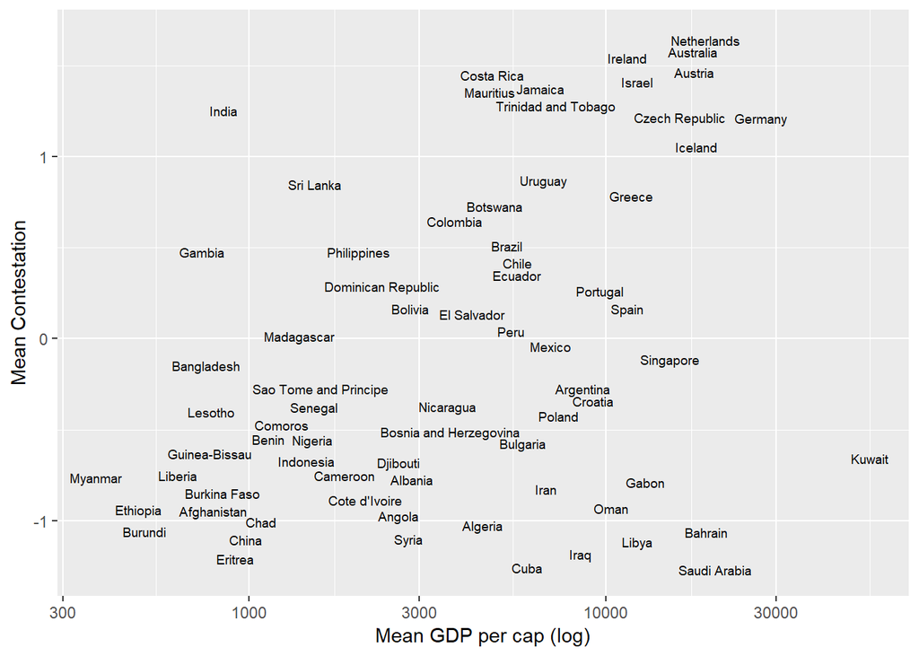

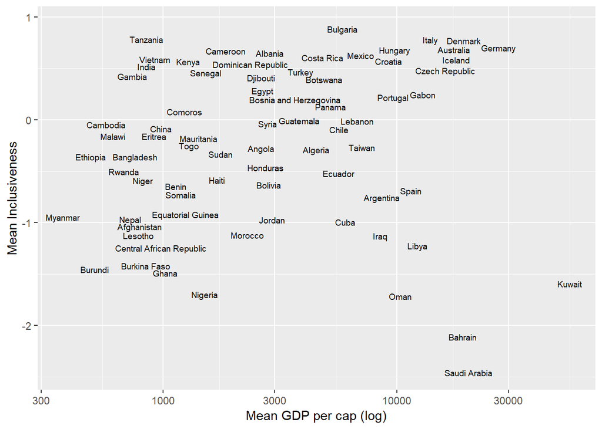

# left_join

A função `left_join` é essencialmente idêntica à função `right_join`, exceto pelo fato de que agora é a primeira base de dados que será inteiramente adicionada à segunda.

```r
#Ajustando os formatos de variáveis para evitar conflitos.
gapminder$year <- as.numeric(gapminder$year)
gapminder$country <- as.character(gapminder$country)
dahl$country <- as.character(dahl$country)


#Cruzando as bases de dados
dahl_gapminder_left <- dahl %>%
  left_join(gapminder, by =c("country", "year"))
nrow(dahl_gapminder_left)
```

```
## [1] 7563
```

# inner_join

A função `inner_join` adiciona à primeira base de dados apenas as observações que encontram paralelo em alguma variável da segunda base de dados. Isto é, apenas observações de linhas em comum são adicionadas.

```r
dahl_gapminder_inner <- dahl %>%
  inner_join(gapminder, by =c("country", "year"))
nrow(dahl_gapminder_inner)
```

```
## [1] 1097
```

# full_join

A função `full_join` adiciona à primeira base de dados todas as observações da segunda base de dados, além de manter todas as observações da primeira.

```r
dahl_gapminder_full <- dahl %>%
  full_join(gapminder, by =c("country", "year"))
nrow(dahl_gapminder_full)
```

```
## [1] 8170
```

Podemos ver que, obviamente, a função `inner_join()` retorna o menor número de missings da variável `CONTEST` da base de dados `dahl`, por exemplo.

```
##       # de Missings de CONTEST
## Inner                        0
## Right                      607
## Left                        29
## Full                       636
```

# Agregando linhas

Podemos querer apenas adicionar linhas a uma base de dados. Nesses casos, podemos usar a função `bind_rows()`.

```r
dahl_subset_1 <- filter(dahl, year >= 1980)
dahl_subset_2 <- filter(dahl, year < 1980)

dahl_original <- dahl_subset_1 %>%
  bind_rows(dahl_subset_2)
  nrow(dahl_original)
```

```
## [1] 7563
```

# Limpando e organizando dados com o pacote tidyr

[figure not shown]

Muitos dos dados que encontramos não vêm preparados corretamente para análise. O conceito de “tidy data” (em tradução livre, “dados arrumados”) é essencial para que possamos organizar nossos dados. Dois princípios básicos definem o conceito de tidy data:

1. Linhas representam observações.
2. Colunas representam variáveis.

É importante lembrar que todos os pacotes do `tidyverse` foram construídos com base no princípio de tidy data, de forma que, se quisermos utilizá-los da melhor forma possível, precisamos ter dados bem organizados. O pacote `tidyr` possui uma série de funções destinadas a transformar dados desorganizados em tidy data.

# Um exemplo de dados desorganizados

Vamos utilizar a base de dados `weather`, que traz previsões do tempo, incluindo variáveis como temperatura, velocidade do vento, humidade do ar e eventos (chuva, neve etc.).

```r
setwd("C:\\Users\\Alessandro Freire\\Downloads")

weather <- readRDS("weather.rds")

head(weather)
```

```
##   X year month           measure X1 X2 X3 X4 X5 X6 X7 X8 X9 X10 X11 X12
## 1 1 2014    12  Max.TemperatureF 64 42 51 43 42 45 38 29 49  48  39  39
## 2 2 2014    12 Mean.TemperatureF 52 38 44 37 34 42 30 24 39  43  36  35
## 3 3 2014    12  Min.TemperatureF 39 33 37 30 26 38 21 18 29  38  32  31
## 4 4 2014    12    Max.Dew.PointF 46 40 49 24 37 45 36 28 49  45  37  28
## 5 5 2014    12    MeanDew.PointF 40 27 42 21 25 40 20 16 41  39  31  27
## 6 6 2014    12     Min.DewpointF 26 17 24 13 12 36 -3  3 28  37  27  25
##   X13 X14 X15 X16 X17 X18 X19 X20 X21 X22 X23 X24 X25 X26 X27 X28 X29 X30
## 1  42  45  42  44  49  44  37  36  36  44  47  46  59  50  52  52  41  30
## 2  37  39  37  40  45  40  33  32  33  39  45  44  52  44  45  46  36  26
## 3  32  33  32  35  41  36  29  27  30  33  42  41  44  37  38  40  30  22
## 4  28  29  33  42  46  34  25  30  30  39  45  46  58  31  34  42  26  10
## 5  26  27  29  36  41  30  22  24  27  34  42  44  43  29  31  35  20   4
## 6  24  25  27  30  32  26  20  20  25  25  37  41  29  28  29  27  10  -6
##   X31
## 1  30
## 2  25
## 3  20
## 4   8
## 5   5
## 6   1
```

Podemos ver que as colunas `X1` a `X31` representam, na verdade, observações diárias referentes às variáveis contidas na coluna `measure`. Por exemplo, a primeira linha da coluna `X1` corresponde à temperatura máxima observada em Fahrenreit (64) no dia 1. O que queremos fazer é colocar as “variáveis” `X1` a `X31` como observações e as “observações” de `measure` como variáveis. Para isso, podemos usar as funções `gather()` e `spread()` do pacote `tidyr`.

# gather

A função `gather()` agrega valores espalhados em diferentes colunas. Essa função possui três argumentos:

1. As colunas representando observações e não variáveis (neste caso, `X1` a `X31`);
2. `key`, o nome da variável que formará a nova coluna (neste caso, a chamaremos de `day`);
3. `value`, o nome da variável cujos valores estão espalhados em diferentes colunas (neste caso, chamaremos de `temperature`).

```r
library(tidyr)
weather_tidy_gather <- weather %>%
  gather(key = "day", value = "temperature", X1:X31, na.rm = TRUE)
head(weather_tidy_gather)
```

```
##   X year month           measure day temperature
## 1 1 2014    12  Max.TemperatureF  X1          64
## 2 2 2014    12 Mean.TemperatureF  X1          52
## 3 3 2014    12  Min.TemperatureF  X1          39
## 4 4 2014    12    Max.Dew.PointF  X1          46
## 5 5 2014    12    MeanDew.PointF  X1          40
## 6 6 2014    12     Min.DewpointF  X1          26
```

Temos uma coluna indesejada, `X`, com o número de linhas. Podemos removê-la da seguinte forma:

```r
weather_tidy_gather <- weather_tidy_gather[,-1]
head(weather_tidy_gather)
```

```
##   year month           measure day temperature
## 1 2014    12  Max.TemperatureF  X1          64
## 2 2014    12 Mean.TemperatureF  X1          52
## 3 2014    12  Min.TemperatureF  X1          39
## 4 2014    12    Max.Dew.PointF  X1          46
## 5 2014    12    MeanDew.PointF  X1          40
## 6 2014    12     Min.DewpointF  X1          26
```

# spread

A função `spread()` faz o contrário da função `gather()`, espalhando os valores únicos de uma coluna em diversas colunas. É o que faremos com a variável `measure`, a qual contém diferentes tipos de medidas de temperatura ao longo de um dia (temperaturas máxima e mínima, ponto de condensação etc.).

```r
weather_tidy_spread <- weather_tidy_gather %>%
  spread(key = measure, value = temperature)

head(weather_tidy_spread)
```

```
##   year month day CloudCover    Events Max.Dew.PointF Max.Gust.SpeedMPH
## 1 2014    12  X1          6      Rain             46                29
## 2 2014    12 X10          8      Rain             45                29
## 3 2014    12 X11          8 Rain-Snow             37                28
## 4 2014    12 X12          7      Snow             28                21
## 5 2014    12 X13          5                       28                23
## 6 2014    12 X14          4                       29                20
##   Max.Humidity Max.Sea.Level.PressureIn Max.TemperatureF
## 1           74                    30.45               64
## 2          100                    29.58               48
## 3           92                    29.81               39
## 4           85                    29.88               39
## 5           75                    29.86               42
## 6           82                    29.91               45
##   Max.VisibilityMiles Max.Wind.SpeedMPH Mean.Humidity
```

[output cut: 34 more lines]

Agora que temos uma base organizada, podemos começar algumas análises exploratórias.

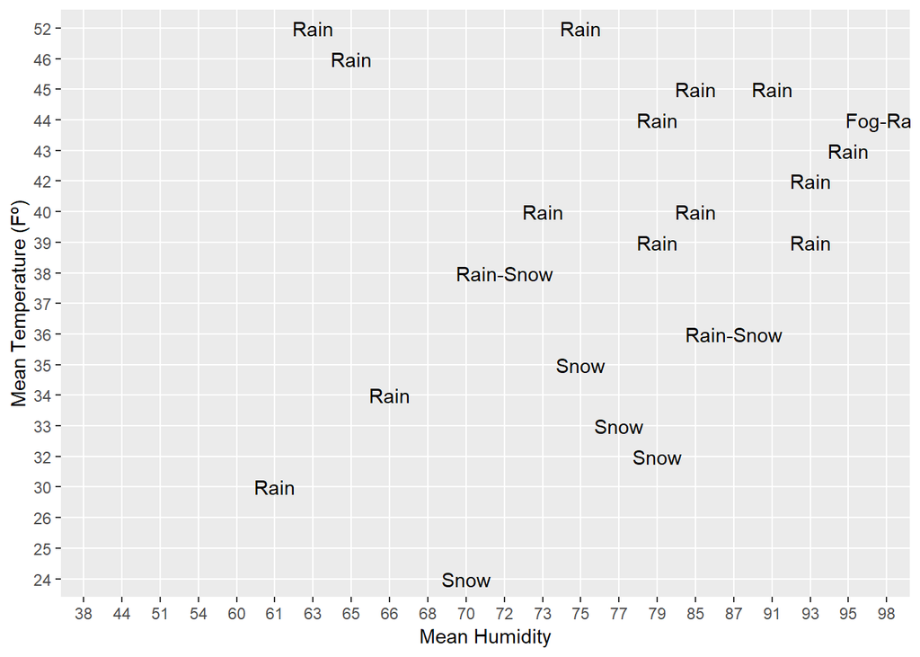

```r
weather_tidy_spread %>%
  filter(year == 2014) %>%
  ggplot(aes(x = Mean.Humidity, y = Mean.TemperatureF, label = Events)) +
  geom_text() +
  xlab("Mean Humidity") + ylab("Mean Temperature (Fº)")
```

# separate

A função `separate()` separa uma variável em duas. Essa função é bastante útil quando estamos lidando com dados desorganizados e sujos. `separate()` possui três argumentos:

1. A base de dados cuja variável queremos separar.
2. A variável que queremos separar.
3. As variáveis que serão originadas após a separação (argumento `into`).

```r
library(gapminder)

head(table3)
```

```
## # A tibble: 6 x 3
##   country      year rate
##   <chr>       <int> <chr>
## 1 Afghanistan  1999 745/19987071
## 2 Afghanistan  2000 2666/20595360
## 3 Brazil       1999 37737/172006362
## 4 Brazil       2000 80488/174504898
## 5 China        1999 212258/1272915272
## 6 China        2000 213766/1280428583
```

Vamos separar a variável `year` em `century` e `year`

```r
table6 <- table3 %>%
  separate(year, into = c("century", "year"), sep = 2)
  head(table6)
```

```
## # A tibble: 6 x 4
##   country     century year  rate
##   <chr>       <chr>   <chr> <chr>
## 1 Afghanistan 19      99    745/19987071
## 2 Afghanistan 20      00    2666/20595360
## 3 Brazil      19      99    37737/172006362
## 4 Brazil      20      00    80488/174504898
## 5 China       19      99    212258/1272915272
## 6 China       20      00    213766/1280428583
```

# unite

A função `unite()` faz o inverso de `separate()`e possui argumentos muito semelhantes.

Vamos unir as variáveis `century` e `year` de volta em uma nova varável chamada `year_complete`.

```r
table6 %>%
  unite("year_complete", century, year, sep = "")
```

```
## # A tibble: 6 x 3
##   country     year_complete rate
##   <chr>       <chr>         <chr>
## 1 Afghanistan 1999          745/19987071
## 2 Afghanistan 2000          2666/20595360
## 3 Brazil      1999          37737/172006362
## 4 Brazil      2000          80488/174504898
## 5 China       1999          212258/1272915272
## 6 China       2000          213766/1280428583
```

# Combinando o dplyr e o tidyr

Agora vamos combinar algumas das funções do `dplyr` e do `tidyr` para organizarmos a base `democracy`, a qual não está em um formato apropriado para análises. Suponha que queiramos analisar dados sobre o Índice de Percepção da Corrupção (CPI, em inglês) dos anos de 1996 a 2007 entre diferentes países.

Primeiro, podemos ver como os dados estão (des)organizados.

```r
library(haven)
library(foreign)
setwd("C:\\Users\\Alessandro Freire\\Downloads")

democracy <- read_spss("Democracy.sav")

head(democracy)
```

```
## # A tibble: 6 x 1,002
##   Refno NATIONCODE Country Nation Natcode Natabrv Natlabel Natmap   ESS
##   <dbl>      <dbl> <chr>   <chr>  <dbl+l> <chr>   <chr>    <chr>  <dbl>
## 1     1         NA  Afgha~ Afgha~ 1       AFG     Afg      Afgha~     0
## 2     2         NA  Alban~ Alban~ 2       ALB     Alb      Alban~     0
## 3     3         NA  Alger~ Alger~ 3       DZA     Alg      Alger~     0
## 4     4         NA  Andor~ Andor~ 4       AND     And      Andor~     0
## 5     5         NA  Angola Angola 5       AGO     Ang      Angola     0
## 6     6         NA  Antig~ Antig~ 6       ANT     Ant      Antig~     0
## # ... with 993 more variables: CSESI <dbl>, CSES2 <dbl>, INWVS <dbl+lbl>,
## #   WVSWave5 <dbl+lbl>, NatWVS <dbl>, v2old <dbl>, NatFH <chr>,
## #   UNDPCode <dbl>, UNDPNat <chr>, TypeDemo2007 <dbl+lbl>,
## #   TypeSoc2005 <dbl+lbl>, TypeEcon2006 <dbl+lbl>, HDI2005 <dbl>,
## #   GDP2006 <dbl>, ZGDP2006 <dbl>, CBINDEX <dbl>, Region8a <dbl+lbl>,
## #   Region8b <dbl+lbl>, Region10 <dbl+lbl>, Region11 <dbl+lbl>,
## #   OECD <dbl+lbl>, EU <dbl+lbl>, Africa <dbl>, Asia <dbl>, CEurope <dbl>,
## #   MEast <dbl>, Nam <dbl>, Sam <dbl>, Scan <dbl>, WEuro <dbl>,
## #   Cultzone <dbl+lbl>, Religion <dbl+lbl>, Protestant <dbl+lbl>,
## #   Catholic <dbl+lbl>, Muslim <dbl+lbl>, Orthodox <dbl+lbl>,
## #   Relcat <dbl+lbl>, Relfree <dbl>, fhrelfr <dbl>, Lang <dbl+lbl>,
## #   Lang1 <dbl>, Lang2 <dbl+lbl>, Lang3 <dbl+lbl>, Lang4 <dbl>,
## #   Lang5 <chr>, foreignborn <dbl>, Colony <dbl+lbl>, Britcol <dbl+lbl>,
## #   Independence <dbl>, Peacebuild <dbl+lbl>, Fragile2006 <dbl+lbl>,
## #   STAND_DEMOCRACY <dbl>, FHstand1975 <dbl>, Fhstand2000 <dbl>,
## #   FHstand2006 <dbl+lbl>, FHstand2007 <dbl>, FHstand2008 <dbl>,
## #   Vanstand2000 <dbl>, Cheibubstand2000 <dbl>, Politystand2000 <dbl>,
## #   Politystand2006 <dbl>, KAUFMANN_KRAY <dbl>, Voice1996 <dbl>,
## #   Voice1998 <dbl>, Voice2000 <dbl>, Voice2002 <dbl>, Voice2003 <dbl>,
## #   Voice2004 <dbl>, Voice2005 <dbl>, Voice2006 <dbl>, Stable1996 <dbl>,
## #   Stable1998 <dbl>, Stable2000 <dbl>, Stable2002 <dbl>,
## #   Stable2003 <dbl>, Stable2004 <dbl>, Stable2005 <dbl>,
## #   Stable2006 <dbl>, Effect1996 <dbl>, Effect1998 <dbl>,
## #   Effect2000 <dbl>, Effect2002 <dbl>, Effect2003 <dbl>,
## #   Effect2004 <dbl>, Effect2005 <dbl>, Effect2006 <dbl>, regul1996 <dbl>,
## #   regul1998 <dbl>, regul2000 <dbl>, regul2002 <dbl>, regul2003 <dbl>,
## #   regul2004 <dbl>, regul2005 <dbl>, regul2006 <dbl>, law1996 <dbl>,
## #   law1998 <dbl>, law2000 <dbl>, law2002 <dbl>, law2003 <dbl>,
## #   law2004 <dbl>, ...
```

Note que não há uma variável de ano nessa base de dados, de forma que muitas observações aparecem como variáveis, em colunas. Por exemplo, temos as “variáveis” `cpi1996`, `cpi2001`, `cpi2002` etc.

Podemos começar a limpeza dos dados selecionando as variáveis que queremos analisar. Neste caso, selecionamos `Nation` e as variáveis `cpi1996` a `cpi2007`.

```r
democracy_cpi <- democracy %>%
  select(Nation, cpi1996:cpi2007)
  head(democracy_cpi, 10)
```

```
## # A tibble: 10 x 9
##    Nation   cpi1996 cpi2001 cpi2002 cpi2003 cpi2004 cpi2005 cpi2006 cpi2007
##    <chr>      <dbl>   <dbl>   <dbl>   <dbl>   <dbl>   <dbl>   <dbl>   <dbl>
##  1 Afghani~   NA      NA      NA       NA      NA      2.51    NA       1.8
##  2 Albania    NA      NA       2.5      2.5     2.5    2.42     2.6     2.9
##  3 Algeria    NA      NA      NA        2.6     2.7    2.84     3.1     3
##  4 Andorra    NA      NA      NA       NA      NA      7.70    NA      NA
##  5 Angola     NA      NA       1.70     1.8     2      2.02     2.2     2.2
##  6 Antigua~   NA      NA      NA       NA      NA      4.61    NA      NA
##  7 Argenti~    3.40    3.5     2.80     2.5     2.5    2.77     2.9     2.9
##  8 Armenia    NA      NA      NA       NA       3.1    2.92     2.9     3
##  9 Austral~    8.60    8.5     8.60     8.8     8.8    8.80     8.7     8.6
## 10 Austria     7.60    7.80    7.80     8       8.4    8.71     8.6     8.1
```

Agora que selecionamos as variáveis de interesse, usamos a função `gather()` para transformar as colunas `cpi1996` a `cpi2007` em linhas de uma única coluna denominada `cpi_index`.

```r
democracy_cpi <- democracy_cpi %>%
  gather(key = "cpi", value = "cpi_index", cpi1996:cpi2007)
  head(democracy_cpi, 10)
```

```
## # A tibble: 10 x 3
##    Nation            cpi     cpi_index
##    <chr>             <chr>       <dbl>
##  1 Afghanistan       cpi1996     NA
##  2 Albania           cpi1996     NA
##  3 Algeria           cpi1996     NA
##  4 Andorra           cpi1996     NA
##  5 Angola            cpi1996     NA
##  6 Antigua & Barbuda cpi1996     NA
##  7 Argentina         cpi1996      3.40
##  8 Armenia           cpi1996     NA
##  9 Australia         cpi1996      8.60
## 10 Austria           cpi1996      7.60
```

```r
democracy_cpi <- democracy_cpi %>%
separate(cpi, into = c("Unnecessary", "year"), sep = "i")
head(democracy_cpi, 10)
```

```
## # A tibble: 10 x 4
##    Nation            Unnecessary year  cpi_index
##    <chr>             <chr>       <chr>     <dbl>
##  1 Afghanistan       cp          1996      NA
##  2 Albania           cp          1996      NA
##  3 Algeria           cp          1996      NA
##  4 Andorra           cp          1996      NA
##  5 Angola            cp          1996      NA
##  6 Antigua & Barbuda cp          1996      NA
##  7 Argentina         cp          1996       3.40
##  8 Armenia           cp          1996      NA
##  9 Australia         cp          1996       8.60
## 10 Austria           cp          1996       7.60
```

Descartamos a coluna `Unnecessary`, que é a segunda.

```r
democracy_cpi <- democracy_cpi[,-2]
head(democracy_cpi, 10)
```

```
## # A tibble: 10 x 3
##    Nation            year  cpi_index
##    <chr>             <chr>     <dbl>
##  1 Afghanistan       1996      NA
##  2 Albania           1996      NA
##  3 Algeria           1996      NA
##  4 Andorra           1996      NA
##  5 Angola            1996      NA
##  6 Antigua & Barbuda 1996      NA
##  7 Argentina         1996       3.40
##  8 Armenia           1996      NA
##  9 Australia         1996       8.60
## 10 Austria           1996       7.60
```

Por fim, podemos transformar a variável `year` em uma variável numérica, para facilitar operações de filtro.

```r
democracy_cpi$year <- as.numeric(democracy_cpi$year)
mean(democracy_cpi$year, na.rm = T)
```

```
## [1] 2003
```

```r
mean(democracy_cpi$cpi_index, na.rm = T)
```

```
## [1] 4.248272
```

# Exercícios

1. Replique a limpeza de dados da base `democracy` selecionando as variáveis `Nation` e as variáveis `Women1990` a `Women2008`. As novas variáveis devem ser denominadas `year` e `Women_index`. Salve a nova base de dados como `democracy_women`. Use o operador pipe para fazer os comandos em uma sequência única.
2. Cruze as bases de dados `democracy_cpi` e `democracy_women` e salve a nova base como `democracy_women_cpi`. A base `democracy_women_cpi` deve conter apenas observações comuns a ambas as bases. Use a variável `year` como chave para o cruzamento. Não se esqueça de transformar a variável de ano em numérica. Quantas linhas tem a nova base de dados?
3. Usando a base `democracy_women_cpi`, agrupe os dados por país e calcule os valores máximos das variáveis `Women_index` (`max_women`) e `cpi_index` (`max_cpi`). Ordene os dados em ordem decrescente de `Women_index` e `cpi_index`. Quais os 6 países com os menores valores dessas variáveis?
4. Com os dados da base `democracy_women_cpi`, construa um diagrama de texto com o pacote `ggplot2` mostrando a associação entre o índice de percepção da corrupção (eixo y) e a participação de mulheres no parlamento (eixo x). Lembre-se que valores mais altos no cpi indicam **menor** percepção de corrupção. Use um filtro para os dados do ano de 2004. Dica: use os argumentos `label = Nation` (dentro de `aes`) e `geom_text(size = 3, check_overlap = TRUE)`.
5. Cruze a base `democracy_cpi` com a base `dahl`, mantendo todas as observações de `democracy_cpi` e dê a ela o nome de `democracy_cpi_dahl`. Construa um diagrama de pontos com as variáveis `cpi_index` (eixo x) e `CONTEST` (eixo y). Lembre-se de padronizar os nomes das variáveis referentes aos países **antes** de fazer o cruzamento dos dados.